# Lesson 4: Job Search

## Key Terms

- U - Number of unemployed persons
- E - Number of employed persons
- V - Number of vacancies (job openings)
- u - Unemployment rate ($u = \frac{U}{LF}*100$)
- LF - Labor force ($LF = E + U$)
- $\theta$ - market tightness ($\theta = \frac{V}{U}$)
- Hires - Unemployed workers who become employed
- Separations - Employed workers who become unemployed
- Filled - Vacancies that become someone who is employed
- Separations - Employed workers who turn into a vacancy

# Matching Function

The flow of hires in an economy can be defined by a matching function $H(U, V)$ where an increase in unemployed or an increase in vacancies increases the number of hires (positively correlated).

Example:
$$H(U, V) = \gamma \sqrt{U} \sqrt{V}$$
where $\gamma$ is a coefficient that determines the matching efficiency.

## Job-Finding Rate ($f$)

The job-finding rate is defined as the probability that you find a job.

$$f = \frac{H(U, V)}{U}$$
Let us use our example:
$$f = \frac{\gamma \sqrt{U} \sqrt{V}}{U}$$
$$f = \frac{\gamma U^{1/2} V^{1/2}}{U} = \gamma U^{-1/2} V^{1/2} = \gamma \frac{V^{1/2}}{U^{1/2}} = \gamma \sqrt{\theta}$$

## Vacancy-Filling rate ($q$)

The vacancy-filling rate is defined as the probability that a vacancy is filled by a firm within a given period.

$$q = \frac{H(U, V)}{V}$$
Let us use our example:
$$q = \frac{\gamma U^{1/2} V^{1/2}}{V^{1/2}} = \gamma U^{1/2} V^{-1/2} = \gamma (\frac{U}{V})^{1/2} = \gamma \frac{1}{\sqrt{\theta}} = \gamma (\theta)^{-1/2}$$

## A look at $f$ and $q$

1. It is easy for unemployed workers to find a job.
2. It is difficult for a firm to fill a vacancy

The two ways this can happen is either an increase in vacancies or a decrease in unemployed workers.

### Averages

- $\frac{1}{f}$ = Average duration of unemployment
- $\frac{1}{q}$ = Average time it takes to fill a vacancy
- $s = /frac{separations}{E}$ - separation rate
- $\frac{1}{s}$ = Average duration of employment

## Steady-State

Let’s look back at the relationships between unemployment and employment:

1. Number of hires can be defined as $f * U$
   - $H(U, V) = f * U$
2. Number of separations can be defined as $s * E$

Steady-state of unemployment would be considered the natural rate of unemployement:
$$f * U = s * E$$

We can solve for the natural rate of unemployment $u*$:
$$u = \frac{U}{LF}$$
$$LF = E + U$$
$$f*U = E*s$$
$$f*U = (LF - U)*s$$
$$f*U = sLF - sU$$
$$sU + fU = sLF$$
$$\frac{(s + f)U}{LF} = s$$
$$u* = \frac{s}{(s + f)}$$
Since we solved the job-finding rate for theta we can write:
$$u* = \frac{s}{(s + f(\theta))}$$

Which can be used to plot the a Bevridge curve:

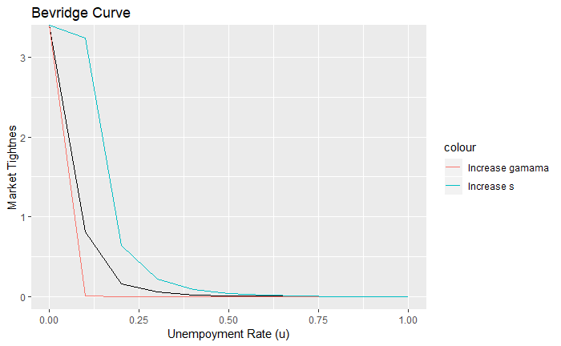

# Supply of Vacancies

A firm will open a vacancy if the marginal benefit of opening that vacancy is greater than or equal to the marginal cost of opening that vacancy. The firm earns a profit off a vacancy due to the output of the person they hire. The profit that the firm earns is $\pi = y - w$ where y is the output of the worker (MPL) and w is their wage (in each period).

If we recall $\frac{1}{s}$ is the average duration of a job and q is the probability of filling a vacancy (vacancy filling rate). This results in:
$$MB = q * (y - w) * \frac{1}{s}$$
Let us denote the cost of opening a vacancy (marginal cost) k. This means that any given firm will continue to open vacancies until:
$$k = q * (y - w) * \frac{1}{s}$$

This is called the vacancy supply condition (free-entry condition).

If we go back to our example we can plug in our value for q:
$$k = \gamma \frac{1}{\sqrt{\theta}} * (y - w) * \frac{1}{s}$$

## Vacancy Supply curve

The vacancy supply curve is a function $\theta (w)$, which we can get by solving our MB = MC equation of vacancies for $\theta$:

$$k = \gamma \frac{1}{\sqrt{\theta}} * (y - w) * \frac{1}{s}$$
$$\sqrt{\theta} = \gamma \frac{1}{k} * (y - w) * \frac{1}{s}$$
$$\theta(w) = (\frac{\gamma * (y - w)}{s * k})^2$$

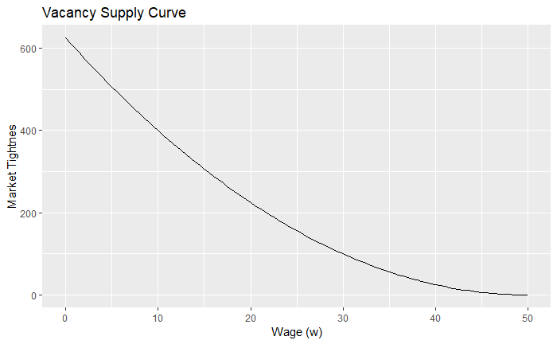

## Shifts in Vacancy Supply

Shifts can be seen within the vacancy supply function:

1. $\gamma$ +
2. y +
3. s -
4. k -

# Wage Formation (Wage-Setting Curve)

There could be a variety of factors that set wages:

- taxes
- y (output per worker)
- education
- minimum wage
- $\beta$ - bargaining power of unions
- b - unemployment benefits
- $\theta$ - market tightness

For us the Wage-Setting (WS) curve will be given. Example:
$$w = \beta y + \beta k \theta + (1 - \beta) b ...$$

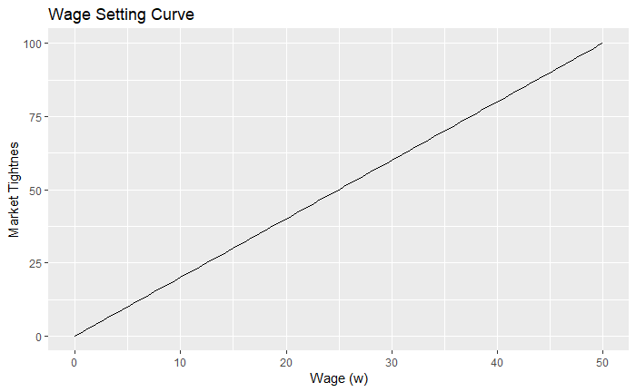

# Summary

We have three curves:

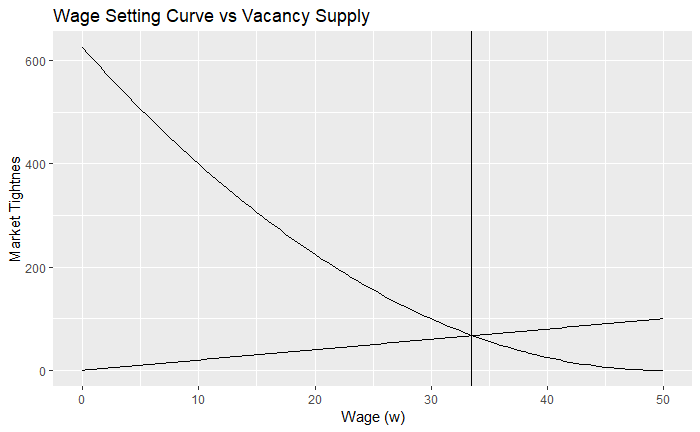

To find the unemployment rate associated with the equilbrium point, just find the unemployment rate on the BC with the same market tightness.